# Phong_Ong_ProjectV2

Load libraries needed

```r
library(tidyverse)
library(cluster)
library(reshape2)
```

```r
library(ggplot2)
library(ggforce)
```

Read in csv file

```r
data <- read_csv("C:/Users/Phong/Documents/Masters/Syracuse/IST707/Project/CC GENERAL.csv")
```

First look at the data

```r
str(data)
```

```
## spec_tbl_df [8,950 x 18] (S3: spec_tbl_df/tbl_df/tbl/data.frame)
##  $ CUST_ID                         : chr [1:8950] "C10001" "C10002" "C10003" "C10004" ...
##  $ BALANCE                         : num [1:8950] 40.9 3202.5 2495.1 1666.7 817.7 ...
##  $ BALANCE_FREQUENCY               : num [1:8950] 0.818 0.909 1 0.636 1 ...
##  $ PURCHASES                       : num [1:8950] 95.4 0 773.2 1499 16 ...
##  $ ONEOFF_PURCHASES                : num [1:8950] 0 0 773 1499 16 ...
##  $ INSTALLMENTS_PURCHASES          : num [1:8950] 95.4 0 0 0 0 ...
##  $ CASH_ADVANCE                    : num [1:8950] 0 6443 0 206 0 ...
##  $ PURCHASES_FREQUENCY             : num [1:8950] 0.1667 0 1 0.0833 0.0833 ...
##  $ ONEOFF_PURCHASES_FREQUENCY      : num [1:8950] 0 0 1 0.0833 0.0833 ...
##  $ PURCHASES_INSTALLMENTS_FREQUENCY: num [1:8950] 0.0833 0 0 0 0 ...
##  $ CASH_ADVANCE_FREQUENCY          : num [1:8950] 0 0.25 0 0.0833 0 ...
##  $ CASH_ADVANCE_TRX                : num [1:8950] 0 4 0 1 0 0 0 0 0 0 ...
##  $ PURCHASES_TRX                   : num [1:8950] 2 0 12 1 1 8 64 12 5 3 ...
##  $ CREDIT_LIMIT                    : num [1:8950] 1000 7000 7500 7500 1200 1800 13500 2300 7000 11000 ...
##  $ PAYMENTS                        : num [1:8950] 202 4103 622 0 678 ...
##  $ MINIMUM_PAYMENTS                : num [1:8950] 140 1072 627 NA 245 ...
##  $ PRC_FULL_PAYMENT                : num [1:8950] 0 0.222 0 0 0 ...
##  $ TENURE                          : num [1:8950] 12 12 12 12 12 12 12 12 12 12 ...
##  - attr(*, "spec")=
##   .. cols(
##   ..   CUST_ID = col_character(),
##   ..   BALANCE = col_double(),
##   ..   BALANCE_FREQUENCY = col_double(),
##   ..   PURCHASES = col_double(),
##   ..   ONEOFF_PURCHASES = col_double(),
##   ..   INSTALLMENTS_PURCHASES = col_double(),
##   ..   CASH_ADVANCE = col_double(),
##   ..   PURCHASES_FREQUENCY = col_double(),
##   ..   ONEOFF_PURCHASES_FREQUENCY = col_double(),
##   ..   PURCHASES_INSTALLMENTS_FREQUENCY = col_double(),
##   ..   CASH_ADVANCE_FREQUENCY = col_double(),
##   ..   CASH_ADVANCE_TRX = col_double(),
##   ..   PURCHASES_TRX = col_double(),
##   ..   CREDIT_LIMIT = col_double(),
##   ..   PAYMENTS = col_double(),
##   ..   MINIMUM_PAYMENTS = col_double(),
##   ..   PRC_FULL_PAYMENT = col_double(),
##   ..   TENURE = col_double()
##   .. )
##  - attr(*, "problems")=<externalptr>
```

```r
summary(data)
```

```
##    CUST_ID             BALANCE        BALANCE_FREQUENCY   PURCHASES
##  Length:8950        Min.   :    0.0   Min.   :0.0000    Min.   :    0.00
##  Class :character   1st Qu.:  128.3   1st Qu.:0.8889    1st Qu.:   39.63
##  Mode  :character   Median :  873.4   Median :1.0000    Median :  361.28
##                     Mean   : 1564.5   Mean   :0.8773    Mean   : 1003.20
##                     3rd Qu.: 2054.1   3rd Qu.:1.0000    3rd Qu.: 1110.13
##                     Max.   :19043.1   Max.   :1.0000    Max.   :49039.57
##
##  ONEOFF_PURCHASES  INSTALLMENTS_PURCHASES  CASH_ADVANCE     PURCHASES_FREQUENCY
##  Min.   :    0.0   Min.   :    0.0        Min.   :    0.0   Min.   :0.00000
##  1st Qu.:    0.0   1st Qu.:    0.0        1st Qu.:    0.0   1st Qu.:0.08333
##  Median :   38.0   Median :   89.0        Median :    0.0   Median :0.50000
##  Mean   :  592.4   Mean   :  411.1        Mean   :  978.9   Mean   :0.49035
##  3rd Qu.:  577.4   3rd Qu.:  468.6        3rd Qu.: 1113.8   3rd Qu.:0.91667
##  Max.   :40761.2   Max.   :22500.0        Max.   :47137.2   Max.   :1.00000
##
##  ONEOFF_PURCHASES_FREQUENCY PURCHASES_INSTALLMENTS_FREQUENCY
##  Min.   :0.00000            Min.   :0.0000
##  1st Qu.:0.00000            1st Qu.:0.0000
##  Median :0.08333            Median :0.1667
##  Mean   :0.20246            Mean   :0.3644
##  3rd Qu.:0.30000            3rd Qu.:0.7500
##  Max.   :1.00000            Max.   :1.0000
##
##  CASH_ADVANCE_FREQUENCY CASH_ADVANCE_TRX  PURCHASES_TRX     CREDIT_LIMIT
##  Min.   :0.0000         Min.   :  0.000   Min.   :  0.00   Min.   :   50
##  1st Qu.:0.0000         1st Qu.:  0.000   1st Qu.:  1.00   1st Qu.: 1600
##  Median :0.0000         Median :  0.000   Median :  7.00   Median : 3000
##  Mean   :0.1351         Mean   :  3.249   Mean   : 14.71   Mean   : 4494
##  3rd Qu.:0.2222         3rd Qu.:  4.000   3rd Qu.: 17.00   3rd Qu.: 6500
##  Max.   :1.5000         Max.   :123.000   Max.   :358.00   Max.   :30000
##                                                            NA's   :1
##     PAYMENTS       MINIMUM_PAYMENTS   PRC_FULL_PAYMENT     TENURE
##  Min.   :    0.0   Min.   :    0.02   Min.   :0.0000   Min.   : 6.00
##  1st Qu.:  383.3   1st Qu.:  169.12   1st Qu.:0.0000   1st Qu.:12.00
##  Median :  856.9   Median :  312.34   Median :0.0000   Median :12.00
##  Mean   : 1733.1   Mean   :  864.21   Mean   :0.1537   Mean   :11.52
##  3rd Qu.: 1901.1   3rd Qu.:  825.49   3rd Qu.:0.1429   3rd Qu.:12.00
##  Max.   :50721.5   Max.   :76406.21   Max.   :1.0000   Max.   :12.00
##                    NA's   :313
```

Data Preprocessing

Remove CUST_ID

```r
mydata <- data[,-1]
mydata <- mydata %>% drop_na()
head(mydata)
```

```
## # A tibble: 6 x 17
##   BALANCE BALANCE_FREQUENCY PURCHASES ONEOFF_PURCHASES INSTALLMENTS_PURCHASES
##     <dbl>             <dbl>     <dbl>            <dbl>                  <dbl>
## 1    40.9             0.818      95.4               0                    95.4
## 2  3202.              0.909       0                 0                     0
## 3  2495.              1         773.              773.                    0
## 4   818.              1          16                16                     0
## 5  1810.              1        1333.                0                  1333.
## 6   627.              1        7091.             6403.                  688.
## # ... with 12 more variables: CASH_ADVANCE <dbl>, PURCHASES_FREQUENCY <dbl>,
## #   ONEOFF_PURCHASES_FREQUENCY <dbl>, PURCHASES_INSTALLMENTS_FREQUENCY <dbl>,
## #   CASH_ADVANCE_FREQUENCY <dbl>, CASH_ADVANCE_TRX <dbl>, PURCHASES_TRX <dbl>,
## #   CREDIT_LIMIT <dbl>, PAYMENTS <dbl>, MINIMUM_PAYMENTS <dbl>,
## #   PRC_FULL_PAYMENT <dbl>, TENURE <dbl>
```

Distance Matrix

```r
distance_mat <- dist(mydata, method = 'euclidean')
```

Hclust

```r
set.seed(11)
hc <- hclust(distance_mat, method = "ward")
```

```
## The "ward" method has been renamed to "ward.D"; note new "ward.D2"
```

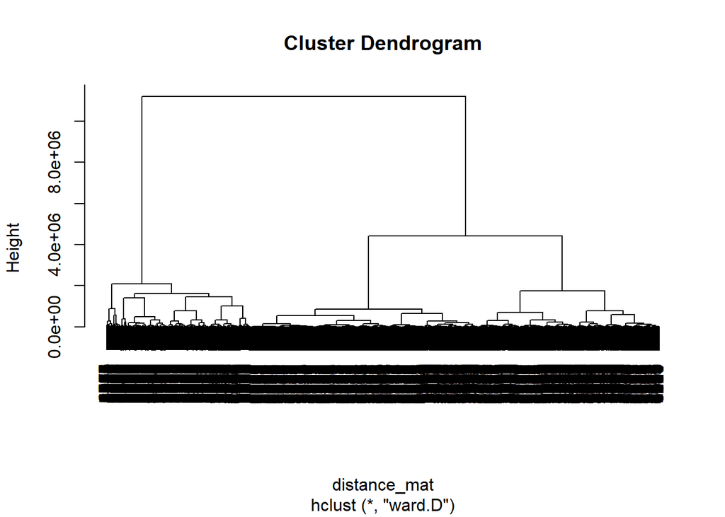

```r
plot(hc)
```

Cut clusters at 4

```r
groups <- cutree(hc, k = 4)
table(groups)
```

```
## groups
##    1    2    3    4
## 3577 2011 2832  216
```

Apply cluster labels to original data

```r
final_data <- cbind(mydata, cluster = groups)
head(final_data)
```

```
##      BALANCE BALANCE_FREQUENCY PURCHASES ONEOFF_PURCHASES
## 1   40.90075          0.818182     95.40             0.00
## 2 3202.46742          0.909091      0.00             0.00
## 3 2495.14886          1.000000    773.17           773.17
## 4  817.71434          1.000000     16.00            16.00
## 5 1809.82875          1.000000   1333.28             0.00
## 6  627.26081          1.000000   7091.01          6402.63
##   INSTALLMENTS_PURCHASES CASH_ADVANCE PURCHASES_FREQUENCY
## 1                  95.40        0.000            0.166667
## 2                   0.00     6442.945            0.000000
## 3                   0.00        0.000            1.000000
## 4                   0.00        0.000            0.083333
## 5                1333.28        0.000            0.666667
## 6                 688.38        0.000            1.000000
##   ONEOFF_PURCHASES_FREQUENCY PURCHASES_INSTALLMENTS_FREQUENCY
```

[output cut: 20 more lines]

Interpretation

```r
hclust(dist(scale(mydata), method = "euclidean"), method = "ward")
```

```
## The "ward" method has been renamed to "ward.D"; note new "ward.D2"
```

```
##
## Call:
## hclust(d = dist(scale(mydata), method = "euclidean"), method = "ward")
##
## Cluster method   : ward.D
## Distance         : euclidean
## Number of objects: 8636
```

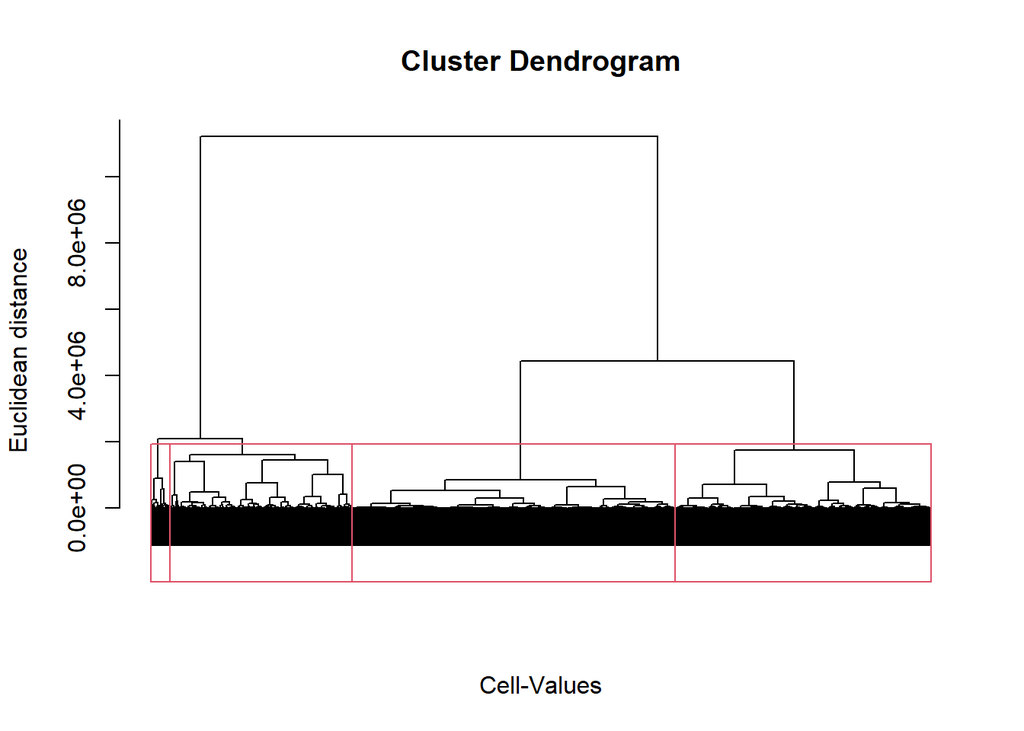

```r
plot(hc, labels = FALSE, sub = "", xlab = "Cell-Values", ylab = "Euclidean distance")
rect.hclust(hc, k = 4)
```

```r
final_results <- aggregate(final_data, by=list(cluster=final_data$cluster), mean)
final_results
```

```
##   cluster   BALANCE BALANCE_FREQUENCY PURCHASES ONEOFF_PURCHASES
## 1       1  582.2765         0.8660671  510.1880         236.7348
## 2       2 3264.2203         0.9432015 1798.2648        1144.1286
## 3       3 1469.4610         0.8946797  610.3176         296.8502
## 4       4 4719.9752         0.9309724 7805.4371        5720.3978
##   INSTALLMENTS_PURCHASES CASH_ADVANCE PURCHASES_FREQUENCY
## 1               273.7425     253.4424           0.4872902
## 2               654.1938    1876.0352           0.5796950
## 3               314.0020     944.5039           0.4362019
## 4              2085.1412    5701.8263           0.6450397
##   ONEOFF_PURCHASES_FREQUENCY PURCHASES_INSTALLMENTS_FREQUENCY
## 1                  0.1274486                        0.3800157
## 2                  0.3465927                        0.4133326
## 3                  0.1823791                        0.3137688
## 4                  0.5039292                        0.4907919
##   CASH_ADVANCE_FREQUENCY CASH_ADVANCE_TRX PURCHASES_TRX CREDIT_LIMIT   PAYMENTS
## 1             0.08416089         1.571149      9.684932     1665.021   801.9288
## 2             0.18805741         5.084038     25.122824     8650.640  2918.8463
## 3             0.15874201         3.667020     10.963983     4684.767  1279.5961
## 4             0.27576657        11.064815     63.018519    11265.278 14114.0627
##   MINIMUM_PAYMENTS PRC_FULL_PAYMENT   TENURE cluster
## 1         424.5761        0.1703580 11.33687       1
## 2        1952.0788        0.1408234 11.72551       2
## 3         547.1035        0.1512004 11.62394       3
## 4        2177.7834        0.2545372 11.85185       4
```

We can take a look at a couple of variables to compare the clusters and determine the types of people in each cluster.

When we look at PURCHASES, this column is the average amount of purchases made from the account. Cluster 1 and 3 seem to be normal consumers spending less than a thousand a month on their credit line. Cluster 2 spend a little more at almost two thousand. This cluster could be more wealthy people. Cluster 4 spends substantially more than any other cluster at almost eight thousand a month. This cluster could be very wealthy people or business accounts.

We can also look at ONEOFF_PURCHASES, which is the average maximum amount purchased in one transaction. Similar to PURCHASES, cluster 1 and 3 are very similar as they have an average max of just under three hundred. Cluster 2 has an average max purchase of 1144 and cluster 4 has an average max purchase of 5720 dollars.

To tie these two columns together, we can look at CREDIT_LIMIT, which is the average limit of credit each person can spend on their credit line. This is where we start to see the clusters separate from each other. Cluster 1 has the smallest credit limit at 1665, cluster 3 comes next at 4684, cluster 2 is next at 8650, and cluster 4 has the highest credit limit at 11265. Even though cluster 1 has a much smaller credit limit than cluster 3, they have almost the same spending behaviors.

PAYMENTS column shows the amount of payment done by the user. In this column the first 3 clusters are closer together but still follow the same patterns with cluster 1 at 800, cluster 3 at 1279, and cluster 2 at 2918. Cluster 4 is substantially more at 14114. Looking at PAYMENTS and CREDIT_LIMIT, we can infer that the users in cluster 4 with higher CREDIT_LIMIT are spending much more than the others in cluster 4 since the average in PAYMENTS is much higher than the average CREDIT_LIMIT.

The last column we will look at is PRC_FULL_PAYMENT which is the average percentage of full payment by the user. The first 3 clusters are similar with cluster 1 at 17%, cluster 2 at 14%, and cluster 3 at 15%. Cluster 4 likes to pay more of the payment at 25%.

Overall, I believe hierarchial clustering did a decent job at separating users into their clusters. We can conclude that each cluster differs in the amount of money each user has available to spend. Cluster 1 are users with the smallest capital, cluster 3 are users with the 2nd smallest capital, cluster 2 are users with the 2nd largest capital, and cluster 4 are users with the highest capital.